# Nordmeyer, Yoon, & Frank, Cogsci 2016

Ann E. Nordmeyer

Analysis for Neginhib (Ann Nordmeyer, Erica Yoon, Mike Frank). The study included three games designed to test the relationship between inhibitory control, implicature processing, and negation processing. All games had a similar structure: participants saw two pictures and heard a word, and had to select the picture that goes with the word as quickly as possible. Each game had two trial types, labeled *control* and *target* in these analyses. The three games were:

**Inhibition Game** : Participants saw several identical trials in a row (e.g. the word “apple” with pictures of an apple and a cookie) and then saw a trial with the same pictures but a different word (e.g. “cookie” with pictures of an apple and a cookie). The repeated trials in each run are the *control* trials and the final trial in each run was the *target* trial, designed to measure inhibitory control.

**Implicature Game**: On *control* / unambiguous trials, participants saw two single pictures (e.g. a picture of an apple and a picture of a cookie) and heard a word referring to one of the pictures (e.g. “apple”). On *target* / implicatures trials, participants saw a picture with a single item and a picture with the same item paired with another item (e.g. a picture of an apple, and a picture of an apple and a cookie) and heard e.g. “apple”. The “correct” response on these trials is the response generated by the ad-hoc implicature, e.g. that “apple” must refer to the single apple because otherwise the speaker would have said “cookie”.

**Negation Game**: On *control* / positive trials, participants saw two pictures and heard a word referring to one of the pictures (e.g. a picture of an apple and a picture of a cookie, with the word “apple”). On *target* / negative trials, participants saw two pictures and heard a word negating one of the pictures (e.g. a picture of an apple and a picture of a cookie, with the words “no apple”).

Kids played these games at the CDM on a computer (4, 5, and 6-year-olds), with 60 trials per game. Adults completed the task on MTurk, with 120 trials per game. The adult version of the task can be viewed here: http://anordmey.github.io/cogsci16/experiment/neginhib_mturk.html

# Setting up

Load required Libraries

```r
rm(list=ls())
library(ggplot2)
library(dplyr)
library(tidyr)
library(magrittr)
library(RWiener)
library(knitr)
library(bootstrap)
library(gridExtra)
library(effsize)
library(lme4)
library(GGally)
```

Some useful functions:

```r
# number of unique subs
n.unique <- function (x) {
  length(unique(x))
}

# for bootstrapping 95% confidence intervals
theta <- function(x,xdata) {mean(xdata[x])}
ci.low <- function(x) {
  quantile(bootstrap(1:length(x),1000,theta,x)$thetastar,.025)}
ci.high <- function(x) {
  quantile(bootstrap(1:length(x),1000,theta,x)$thetastar,.975)}
```

Load in data

RT trimming:

- Planned analysis: +/- 3SDs in log space
- Post-hoc: also trim decisions < 200 ms from word onsent, > 15s (!) after offset, do this before planned outlier exclusion, doesn’t change the results but makes things more reasonable.

```r
d.turk <- read.csv("./data/long_data_mturk.csv")
n.turk.initial <- n.unique(d.turk$subid)

d.turk <- d.turk %>%
  # remove anyone who played fewer than 300 trials (means they did not complete at least half of the third game) or over 408 trials (means they completed the task twice, because 408 is max number of trials -- this only happened for one participant and I'm not sure how they were able to do this, so I'm rejecting them)
  mutate(subid = factor(subid)) %>%
  group_by(subid) %>%
  mutate(ntrials = n()) %>%
  filter(ntrials > 300 & ntrials < 408) %>%
  ungroup() %>%
  # create resp and rt vars
  mutate(resp = factor(response, levels=c("Y","N"), labels=c("upper","lower")),
         q = rt/1000) %>%
  # remove outlier RTs
  filter(rt > 200,
         rt < 15000) %>%
  filter(log(rt) < mean(log(rt)) + 3 * sd(log(rt)),
         log(rt) > mean(log(rt)) - 3 * sd(log(rt))) %>%
  # clean up
  select(subid, game, trial.num, trial.type, q, resp) %>%
  mutate(agegroup = "adults") %>%
  ungroup()
n.turk.final <- n.unique(d.turk$subid)

d.cdm.raw <- read.csv("./data/long_data_cdm.csv") %>%
  filter(agegroup == 4 | agegroup == 5 | agegroup == 6)
n.cdm.initial <- n.unique(d.cdm.raw$subid)

d.cdm <- d.cdm.raw %>%
  # remove any child who played fewer than 150 trials (means they didn't complete at least half of the final game)
  group_by(subid) %>%
  mutate(ntrials = n()) %>%
  filter(ntrials > 150) %>%
  ungroup() %>%
  mutate(resp = factor(response, levels=c("Y","N"), labels=c("upper","lower")),
         q = rt/1000) %>%
  # remove outlier RTs
  filter(rt > 200,
         rt < 15000) %>%
  filter(log(rt) < mean(log(rt)) + 3 * sd(log(rt)),
         log(rt) > mean(log(rt)) - 3 * sd(log(rt))) %>%
  ungroup()
m_age_comp <- aggregate(age ~ agegroup, d.cdm, mean)
min_age_comp <- aggregate(age ~ agegroup, d.cdm, min)
max_age_comp <- aggregate(age ~ agegroup, d.cdm, max)

d.cdm <- d.cdm %>%
  # clean up
  select(subid, age, agegroup, game, trial.num, trial.type, q, resp) %>%
  mutate(agegroup = factor(agegroup)) %>%
  ungroup()
n.cdm.final <- n.unique(d.cdm$subid)
ns.cdm <- aggregate(subid ~ agegroup, d.cdm, n.unique)

d <- bind_rows(d.turk, d.cdm)

d$subid <- factor(d$subid)

d$agegroup <- factor(d$agegroup, levels = c("adults", "4", "5", "6"))

d$trial.labels <- factor(d$trial.type, levels = c("control", "inhib", "unambiguous", "implicature", "positive", "negative"))

d$correct <- as.numeric(as.character(factor(d$resp,
                                            levels=c("upper","lower"),
                                            labels=c("1","0"))))==1

d$trial.type <- factor(d$trial.type %in% c("inhib","implicature","negative"),
                       levels = c(FALSE, TRUE),
                       labels = c("control","target"))

d$game <- factor(d$game, levels=c("inhibition","implicature","negation"))

d <- d %>%
  mutate(agegroup2 = ifelse(agegroup == "adults", "adults", "kids"))
```

We excluded 2 adult participants and 24 child participants for failing to complete at least half of the trials in each game. This left a final sample of 48 adult participants and 66 child participants (22 4-year-olds (age range 4.01-4.99, mean age = 4.6), 19 5-year-olds (age range 5.03-5.95, mean age = 5.49), and 25 6-year-olds (age range 6-6.99, mean age = 6.46)).

# Initial analysis

## Proportion Correct

Proportion correct:

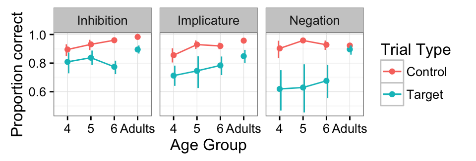

```r
ms.acc <- d %>%
  group_by(game, trial.type, subid, agegroup) %>%
  summarise(m = mean(correct)) %>%
  group_by(game, trial.type, agegroup) %>%
  summarise(cih = ci.high(m),
            cil = ci.low(m),
            m = mean(m))
ms.acc$agegroup <- factor(ms.acc$agegroup,
                      levels = c("4", "5", "6", "adults"),
                      labels =  c("4", "5", "6", "Adults"))
ms.acc$trial.type <- factor(ms.acc$trial.type, labels = c("Control", "Target"))
ms.acc$game <- factor(ms.acc$game, labels = c("Inhibition", "Implicature", "Negation"))
ms.acc$kid <- ms.acc$agegroup != "Adults"

qplot(data = ms.acc, x = agegroup, y = m, color = trial.type,
      geom = "point", position = position_dodge(.2)) +
  geom_errorbar(aes(ymin = cil, ymax = cih),
                position = position_dodge(.2), width = 0) +
  geom_line(aes(group = interaction(kid,trial.type), col = trial.type)) +
  facet_grid( ~ game) +
  ylab("Proportion correct") + xlab("Age Group") +
  scale_color_hue(name = "Trial Type") +
  theme_bw()
```

In general, both adults and kids have lower accuracy on target trials. Kids are much less accurate than adults on target trials, especially in the implicature and negation games.

Do kids differ from adults in accuracy?

```r
##Inhibition:
correct.inhib <- glmer(correct ~ trial.type * agegroup2 + (trial.type | subid),
                             data = filter(d, game == "inhibition"),
                             family = "binomial")
kable(summary(correct.inhib)$coefficients, digits = 3)
```

|  | Estimate | Std. Error | z value | Pr(>\|z\|) |
| --- | --- | --- | --- | --- |
| (Intercept) | 4.486 | 0.189 | 23.753 | 0.000 |
| trial.typetarget | -2.090 | 0.198 | -10.553 | 0.000 |
| agegroup2kids | -1.432 | 0.235 | -6.100 | 0.000 |
| trial.typetarget:agegroup2kids | 0.603 | 0.242 | 2.491 | 0.013 |

```r
##Implicature:
correct.imp <- glmer(correct ~ trial.type * agegroup2 + (trial.type | subid),
                             data = filter(d, game == "implicature"),
                             family = "binomial")
kable(summary(correct.imp)$coefficients, digits = 3)
```

|  | Estimate | Std. Error | z value | Pr(>\|z\|) |
| --- | --- | --- | --- | --- |
| (Intercept) | 3.371 | 0.156 | 21.565 | 0.000 |
| trial.typetarget | -1.142 | 0.215 | -5.320 | 0.000 |
| agegroup2kids | -0.923 | 0.197 | -4.692 | 0.000 |
| trial.typetarget:agegroup2kids | 0.114 | 0.276 | 0.415 | 0.678 |

```r
##Negation:
correct.neg <- glmer(correct ~ trial.type * agegroup2 + (trial.type | subid),
                             data = filter(d, game == "negation"),
                             family = "binomial")
kable(summary(correct.neg)$coefficients, digits = 3)
```

|  | Estimate | Std. Error | z value | Pr(>\|z\|) |
| --- | --- | --- | --- | --- |
| (Intercept) | 2.746 | 0.158 | 17.366 | 0.000 |
| trial.typetarget | -0.179 | 0.276 | -0.649 | 0.516 |
| agegroup2kids | 0.272 | 0.222 | 1.224 | 0.221 |
| trial.typetarget:agegroup2kids | -2.076 | 0.372 | -5.583 | 0.000 |

Is there developmental change in accuracy from 4 to 6 years?

```r
##Inhibition:
correct.inhib.kids <- glmer(correct ~ trial.type * age + (trial.type | subid),
                             data = filter(d, game == "inhibition",
                                           agegroup != "adults"),
                             family = "binomial")
kable(summary(correct.inhib.kids)$coefficients, digits = 3)
```

|  | Estimate | Std. Error | z value | Pr(>\|z\|) |
| --- | --- | --- | --- | --- |
| (Intercept) | 0.286 | 0.987 | 0.289 | 0.772 |
| trial.typetarget | 2.000 | 0.990 | 2.019 | 0.044 |
| age | 0.508 | 0.178 | 2.856 | 0.004 |
| trial.typetarget:age | -0.647 | 0.177 | -3.657 | 0.000 |

```r
##Implicature:
correct.imp.kids <- glmer(correct ~ trial.type * age + (trial.type | subid),
                             data = filter(d, game == "implicature",
                                           agegroup != "adults"),
                             family = "binomial")
kable(summary(correct.imp.kids)$coefficients, digits = 3)
```

|  | Estimate | Std. Error | z value | Pr(>\|z\|) |
| --- | --- | --- | --- | --- |
| (Intercept) | 0.820 | 0.819 | 1.001 | 0.317 |
| trial.typetarget | -0.535 | 1.260 | -0.425 | 0.671 |
| age | 0.294 | 0.146 | 2.006 | 0.045 |
| trial.typetarget:age | -0.089 | 0.225 | -0.398 | 0.691 |

```r
##Negation:
correct.neg.kids <- glmer(correct ~ trial.type * age + (trial.type | subid),
                             data = filter(d, game == "negation",
                                           agegroup != "adults"),
                             family = "binomial")
kable(summary(correct.neg.kids)$coefficients, digits = 3)
```

|  | Estimate | Std. Error | z value | Pr(>\|z\|) |
| --- | --- | --- | --- | --- |
| (Intercept) | 3.429 | 1.289 | 2.660 | 0.008 |
| trial.typetarget | -3.248 | 2.211 | -1.469 | 0.142 |
| age | -0.044 | 0.226 | -0.197 | 0.844 |
| trial.typetarget:age | 0.149 | 0.392 | 0.381 | 0.704 |

## Reaction time

What about reaction time? Here we just look at RTs on correct trials (outlier RTs were trimmed earlier when the data was loaded).

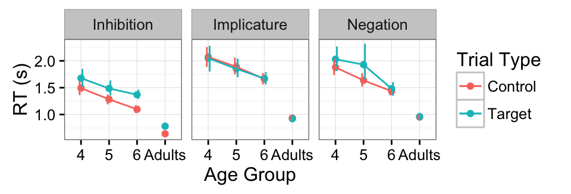

```r
#Plot data
ms.rt <- d %>%
  filter(correct == TRUE) %>%
  group_by(game, trial.type, subid, agegroup) %>%
  summarise(m = mean(q)) %>%
  group_by(game, trial.type, agegroup) %>%
  summarise(cih = ci.high(m),
            cil = ci.low(m),
            m = mean(m))
ms.rt$agegroup <- factor(ms.rt$agegroup,
                      levels = c("4", "5", "6", "adults"),
                      labels = c("4", "5", "6", "Adults"))
ms.rt$game <- factor(ms.rt$game, labels = c("Inhibition", "Implicature", "Negation"))
ms.rt$trial.type <- factor(ms.rt$trial.type, labels = c("Control", "Target"))

ms.rt$kid <- ms.rt$agegroup != "Adults"
qplot(data = ms.rt, x = agegroup, y = m, color = trial.type,
      geom = "point", position = position_dodge(.2)) +
  geom_errorbar(aes(ymin = cil, ymax = cih),
                position = position_dodge(.2), width = 0) +
  geom_line(aes(group = interaction(kid,trial.type), col = trial.type)) +
  facet_grid( ~ game) +
  ylab("RT (s)") + xlab("Age Group") +
  scale_color_hue(name = "Trial Type") +
  theme_bw()
```

Are kids significantly slower than adults?

```r
##Inhibition:
rt.inhib <- lmer(q ~ trial.type * agegroup2 + (trial.type | subid),
                             data = filter(d, game == "inhibition",
                                           correct == TRUE))
kable(summary(rt.inhib)$coefficients, digits = 3)
```

|  | Estimate | Std. Error | t value |
| --- | --- | --- | --- |
| (Intercept) | 0.641 | 0.034 | 18.880 |
| trial.typetarget | 0.140 | 0.014 | 9.757 |
| agegroup2kids | 0.639 | 0.045 | 14.228 |
| trial.typetarget:agegroup2kids | 0.092 | 0.023 | 3.972 |

```r
##Implicature:
rt.imp <- lmer(q ~ trial.type * agegroup2 + (trial.type | subid),
                             data = filter(d, game == "implicature",
                                           correct == TRUE))
kable(summary(rt.imp)$coefficients, digits = 3)
```

|  | Estimate | Std. Error | t value |
| --- | --- | --- | --- |
| (Intercept) | 0.933 | 0.045 | 20.577 |
| trial.typetarget | -0.011 | 0.029 | -0.395 |
| agegroup2kids | 0.930 | 0.060 | 15.453 |
| trial.typetarget:agegroup2kids | -0.014 | 0.040 | -0.354 |

```r
##Negation:
rt.neg <- lmer(q ~ trial.type * agegroup2 + (trial.type | subid),
                             data = filter(d, game == "negation",
                                           correct == TRUE))
kable(summary(rt.neg)$coefficients, digits = 3)
```

|  | Estimate | Std. Error | t value |
| --- | --- | --- | --- |
| (Intercept) | 0.952 | 0.040 | 23.514 |
| trial.typetarget | 0.009 | 0.028 | 0.324 |
| agegroup2kids | 0.690 | 0.054 | 12.828 |
| trial.typetarget:agegroup2kids | 0.116 | 0.040 | 2.910 |

Do kids RTs change developmentally?

```r
##Inhibition:
rt.inhib.kids <- lmer(q ~ trial.type * age + (trial.type | subid),
                             data = filter(d, game == "inhibition",
                                           agegroup != "adults",
                                           correct == TRUE))
kable(summary(rt.inhib.kids)$coefficients, digits = 3)
```

|  | Estimate | Std. Error | t value |
| --- | --- | --- | --- |
| (Intercept) | 2.475 | 0.202 | 12.278 |
| trial.typetarget | 0.085 | 0.190 | 0.445 |
| age | -0.215 | 0.036 | -5.994 |
| trial.typetarget:age | 0.026 | 0.034 | 0.781 |

```r
##Implicature:
rt.imp.kids <- lmer(q ~ trial.type * age + (trial.type | subid),
                             data = filter(d, game == "implicature",
                                           agegroup != "adults",
                                           correct == TRUE))
kable(summary(rt.imp.kids)$coefficients, digits = 3)
```

|  | Estimate | Std. Error | t value |
| --- | --- | --- | --- |
| (Intercept) | 3.113 | 0.296 | 10.514 |
| trial.typetarget | -0.179 | 0.260 | -0.687 |
| age | -0.225 | 0.053 | -4.268 |
| trial.typetarget:age | 0.027 | 0.046 | 0.586 |

```r
##Negation:
rt.neg.kids <- lmer(q ~ trial.type * age + (trial.type | subid),
                             data = filter(d, game == "negation",
                                           agegroup != "adults",
                                           correct == TRUE))
kable(summary(rt.neg.kids)$coefficients, digits = 3)
```

|  | Estimate | Std. Error | t value |
| --- | --- | --- | --- |
| (Intercept) | 2.990 | 0.246 | 12.176 |
| trial.typetarget | 0.341 | 0.257 | 1.324 |
| age | -0.242 | 0.044 | -5.549 |
| trial.typetarget:age | -0.038 | 0.045 | -0.843 |

## Individual Differences

Is there any correlation between an individual’s performance on one game vs. another game?

First let’s look at individual differences in accuracy for adults:

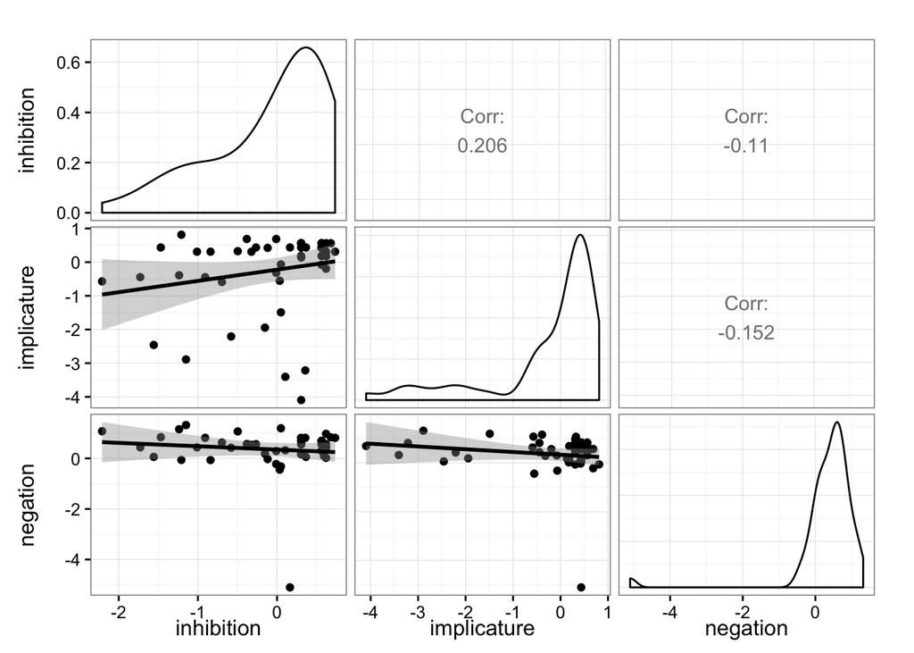

```r
ms.acc.adults <- d %>%
  filter(agegroup2 == "adults") %>%
  group_by(subid, game, trial.type) %>%
  summarise(correct = mean(correct)) %>%
  spread(trial.type, correct) %>%
  mutate(sdiff = scale(target - control)) %>%
  select(-control, -target) %>%
  spread(game, sdiff)

ggpairs(data = ms.acc.adults,
        columns = 2:4,
        upper = list(continuous = "cor"),
        lower = list(continuous = "smooth")) +
  theme_bw()
```

```r
cor.test(ms.acc.adults$inhibition, ms.acc.adults$implicature)
```

```
##
##  Pearson's product-moment correlation
##
## data:  ms.acc.adults$inhibition and ms.acc.adults$implicature
## t = 1.4267, df = 46, p-value = 0.1604
## alternative hypothesis: true correlation is not equal to 0
## 95 percent confidence interval:
##  -0.08314126  0.46291482
## sample estimates:
##       cor
## 0.2058565
```

```r
cor.test(ms.acc.adults$inhibition, ms.acc.adults$negation)
```

```
##
##  Pearson's product-moment correlation
##
## data:  ms.acc.adults$inhibition and ms.acc.adults$negation
## t = -0.75017, df = 46, p-value = 0.457
## alternative hypothesis: true correlation is not equal to 0
## 95 percent confidence interval:
##  -0.3821342  0.1798154
## sample estimates:
##        cor
## -0.1099361
```

```r
cor.test(ms.acc.adults$negation, ms.acc.adults$implicature)
```

```
##
##  Pearson's product-moment correlation
##
## data:  ms.acc.adults$negation and ms.acc.adults$implicature
## t = -1.0408, df = 46, p-value = 0.3034
## alternative hypothesis: true correlation is not equal to 0
## 95 percent confidence interval:
##  -0.4178127  0.1384149
## sample estimates:
##        cor
## -0.1516854
```

What about kids’ accuracy?

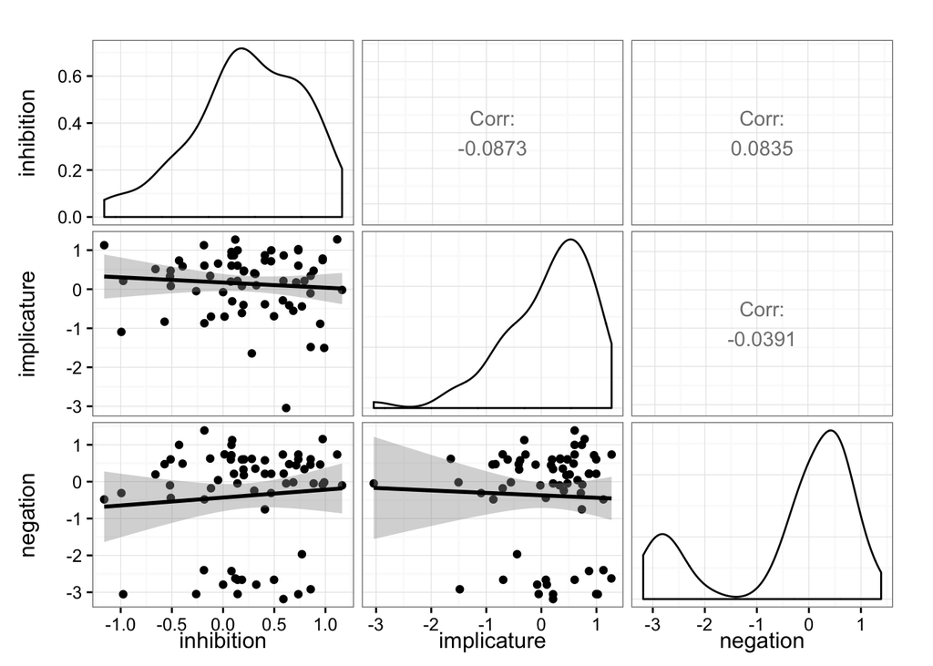

```r
ms.acc.kids <- d %>%
  filter(agegroup2 == "kids") %>%
  group_by(subid, game, trial.type) %>%
  summarise(correct = mean(correct)) %>%
  spread(trial.type, correct) %>%
  mutate(sdiff = scale(target - control)) %>%
  select(-control, -target) %>%
  spread(game, sdiff)

ggpairs(data = ms.acc.kids,
        columns = 2:4,
        upper = list(continuous = "cor"),
        lower = list(continuous = "smooth")) +
  theme_bw()
```

```r
cor.test(ms.acc.kids$inhibition, ms.acc.kids$implicature)
```

```
##
##  Pearson's product-moment correlation
##
## data:  ms.acc.kids$inhibition and ms.acc.kids$implicature
## t = -0.70116, df = 64, p-value = 0.4857
## alternative hypothesis: true correlation is not equal to 0
## 95 percent confidence interval:
##  -0.3225278  0.1580623
## sample estimates:
##        cor
## -0.0873107
```

```r
cor.test(ms.acc.kids$inhibition, ms.acc.kids$negation)
```

```
##
##  Pearson's product-moment correlation
##
## data:  ms.acc.kids$inhibition and ms.acc.kids$negation
## t = 0.66994, df = 64, p-value = 0.5053
## alternative hypothesis: true correlation is not equal to 0
## 95 percent confidence interval:
##  -0.1618514  0.3190393
## sample estimates:
##        cor
## 0.08345038
```

```r
cor.test(ms.acc.kids$negation, ms.acc.kids$implicature)
```

```
##
##  Pearson's product-moment correlation
##
## data:  ms.acc.kids$negation and ms.acc.kids$implicature
## t = -0.3134, df = 64, p-value = 0.755
## alternative hypothesis: true correlation is not equal to 0
## 95 percent confidence interval:
##  -0.2785385  0.2048286
## sample estimates:
##         cor
## -0.03914474
```

Now let’s look at individual differences in reaction time for adults:

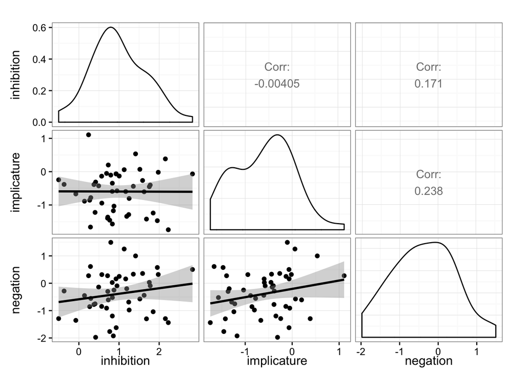

```r
ms.rt.adults <- d %>%
  filter(correct == TRUE, agegroup2 == "adults") %>%
  group_by(subid, game, trial.type) %>%
  summarise(rt = mean(q)) %>%
  spread(trial.type, rt) %>%
  mutate(sdiff = scale(target - control)) %>%
  select(-control, -target) %>%
  spread(game, sdiff)

ggpairs(data = ms.rt.adults,
        columns = 2:4,
        upper = list(continuous = "cor"),
        lower = list(continuous = "smooth")) +
  theme_bw()
```

```r
cor.test(ms.rt.adults$inhibition, ms.rt.adults$implicature)
```

```
##
##  Pearson's product-moment correlation
##
## data:  ms.rt.adults$inhibition and ms.rt.adults$implicature
## t = -0.027447, df = 46, p-value = 0.9782
## alternative hypothesis: true correlation is not equal to 0
## 95 percent confidence interval:
##  -0.2878505  0.2804103
## sample estimates:
##          cor
## -0.004046784
```

```r
cor.test(ms.rt.adults$inhibition, ms.rt.adults$negation)
```

```
##
##  Pearson's product-moment correlation
##
## data:  ms.rt.adults$inhibition and ms.rt.adults$negation
## t = 1.1787, df = 46, p-value = 0.2446
## alternative hypothesis: true correlation is not equal to 0
## 95 percent confidence interval:
##  -0.1186789  0.4342378
## sample estimates:
##       cor
## 0.1712298
```

```r
cor.test(ms.rt.adults$negation, ms.rt.adults$implicature)
```

```
##
##  Pearson's product-moment correlation
##
## data:  ms.rt.adults$negation and ms.rt.adults$implicature
## t = 1.6619, df = 46, p-value = 0.1033
## alternative hypothesis: true correlation is not equal to 0
## 95 percent confidence interval:
##  -0.04948956  0.48905563
## sample estimates:
##       cor
## 0.2379917
```

What about kids’ RT?

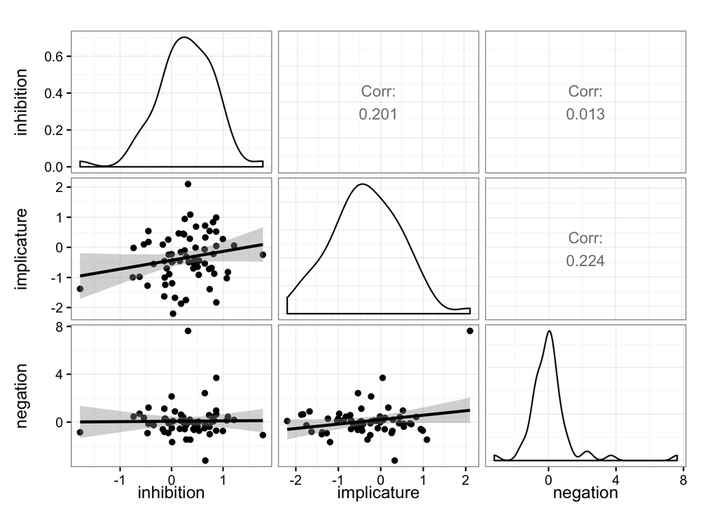

```r
ms.rt.kids <- d %>%
  filter(correct == TRUE, agegroup2 == "kids") %>%
  group_by(subid, game, trial.type) %>%
  summarise(rt = mean(q)) %>%
  spread(trial.type, rt) %>%
  mutate(sdiff = scale(target - control)) %>%
  select(-control, -target) %>%
  spread(game, sdiff)

ggpairs(data = ms.rt.kids,
        columns = 2:4,
        upper = list(continuous = "cor"),
        lower = list(continuous = "smooth")) +
  theme_bw()
```

```r
cor.test(ms.rt.kids$inhibition, ms.rt.kids$implicature)
```

```
##
##  Pearson's product-moment correlation
##
## data:  ms.rt.kids$inhibition and ms.rt.kids$implicature
## t = 1.6442, df = 64, p-value = 0.105
## alternative hypothesis: true correlation is not equal to 0
## 95 percent confidence interval:
##  -0.04279977  0.42275234
## sample estimates:
##       cor
## 0.2013185
```

```r
cor.test(ms.rt.kids$inhibition, ms.rt.kids$negation)
```

```
##
##  Pearson's product-moment correlation
##
## data:  ms.rt.kids$inhibition and ms.rt.kids$negation
## t = 0.10134, df = 61, p-value = 0.9196
## alternative hypothesis: true correlation is not equal to 0
## 95 percent confidence interval:
##  -0.2355476  0.2599041
## sample estimates:
##        cor
## 0.01297461
```

```r
cor.test(ms.rt.kids$negation, ms.rt.kids$implicature)
```

```
##
##  Pearson's product-moment correlation
##
## data:  ms.rt.kids$negation and ms.rt.kids$implicature
## t = 1.7939, df = 61, p-value = 0.07779
## alternative hypothesis: true correlation is not equal to 0
## 95 percent confidence interval:
##  -0.02531557  0.44683569
## sample estimates:
##       cor
## 0.2238535
```

# Diffusion Analysis

For the diffusion analysis, we estimated parameters separately for each trial type within each game. Parameters are estimated within each subject and then we aggregate across subjects to get means & confidence intervals on the parameters.

## Plot densities

Plots show density of RTs for correct and incorrect responses, for each trial type. You can see the speed-accuracy tradeoff in some of these plots, especially the inhibition trials.

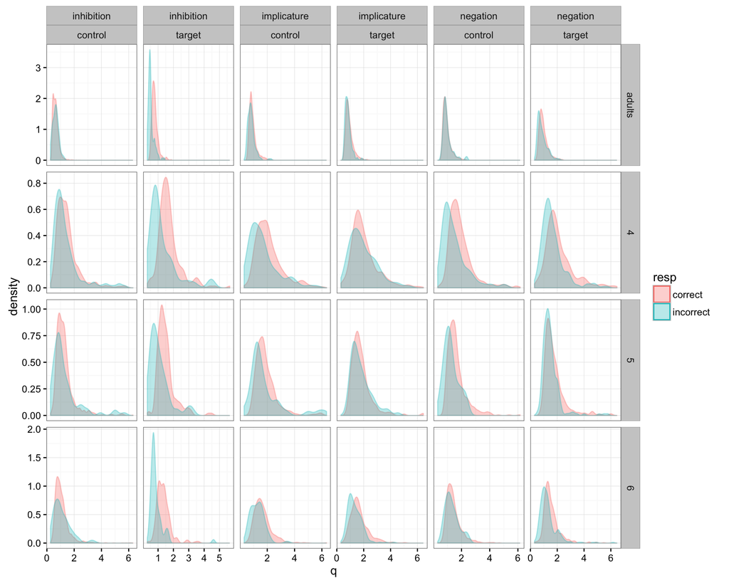

```r
#Make a bunch of plots:
ggplot(d, aes(x = q)) +
  geom_density(aes(group = resp, colour = resp, fill = resp), alpha = 0.3) +
  facet_grid(agegroup ~ game + trial.type, scales = "free") +
  scale_fill_hue(labels = c("correct", "incorrect")) +
  scale_color_hue(labels = c("correct", "incorrect")) +
  theme_bw()
```

## Estimating parameters

We calculated parameters for each trial type separately, within each subject. Then we aggregated across subjects to get means & confidence intervals on the parameters, and plotted the parameters across each game & trial type.

```r
sub.pars <- data.frame(Separation = numeric(),
                       Non.Decision = numeric(),
                       Bias = numeric(),
                       Drift = numeric(),
                       Trial.Type = character(),
                       SubID = character(),
                       Age = character())
sub.pars$Trial.Type <- as.character(sub.pars$Trial.Type)
sub.pars$SubID <- as.character(sub.pars$SubID)
sub.pars$Age <- as.character(sub.pars$Age)

temp.pars <- sub.pars

#because RWiener is finicky:
d$resp <- as.character(d$resp)
```

```r
trialtypes <- c("control", "inhib", "unambiguous", "implicature", "positive", "negative")
subs <- unique(d$subid)

for (j in 1:length(subs)) {
  sid <- as.character(subs[j])
  for (i in 1:length(trialtypes)) {
    ttype <- as.character(trialtypes[i])
    dat <- as.data.frame(subset(d, trial.labels == ttype & subid == sid))
    opt <- optim(c(1, .1, .1, 1), wiener_deviance,
                 dat=select(dat, c(q, resp)), method="Nelder-Mead")
    pars <- c(opt$par, ttype, sid, as.character(dat$agegroup[1]))
    temp.pars[i,] <- pars
  }
  sub.pars <- rbind(temp.pars, sub.pars)
  temp.pars <- temp.pars[0, ]
}
```

### Plot Parameters

This plot shows the mean parameter values & 95% C.I.s for each game/trial type.

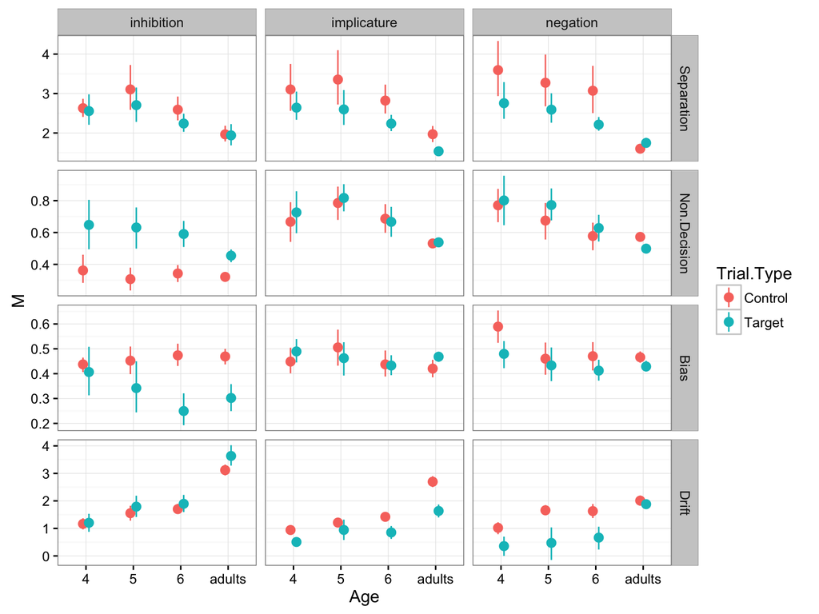

```r
sub.pars <- sub.pars %>%
  mutate(Game = ifelse(Trial.Type == "control" | Trial.Type == "inhib", "inhibition", ifelse(Trial.Type == "positive" | Trial.Type == "negative", "negation", "implicature")),
         Trial.Type = ifelse(Trial.Type == "control" | Trial.Type == "positive" | Trial.Type == "unambiguous", "Control", "Target"))

sub.pars$Separation <- as.numeric(sub.pars$Separation)
sub.pars$Non.Decision <- as.numeric(sub.pars$Non.Decision)
sub.pars$Bias <- as.numeric(sub.pars$Bias)
sub.pars$Drift <- as.numeric(sub.pars$Drift)
sub.pars$Kids <- sub.pars$Age != "adults"

sub.pars <- sub.pars %>%
  group_by(Game, Kids) %>%
  filter(Separation < mean(Separation) + 3 * sd(Separation),
         Separation > mean(Separation) - 3 * sd(Separation)) %>%
  filter(Non.Decision < mean(Non.Decision) + 3 * sd(Non.Decision),
         Non.Decision > mean(Non.Decision) - 3 * sd(Non.Decision)) %>%
  filter(Bias < mean(Bias) + 3 * sd(Bias),
         Bias > mean(Bias) - 3 * sd(Bias)) %>%
  filter(Drift < mean(Drift) + 3 * sd(Drift),
         Drift > mean(Drift) - 3 * sd(Drift)) %>%
  ungroup() %>%
  na.omit()

sub.pars.ms <- sub.pars %>%
  gather(Param, Value, Separation:Drift) %>%
  group_by(Age, Trial.Type, Game, Param) %>%
  summarise(M = mean(Value),
            cih = ci.high(Value),
            cil = ci.low(Value))
sub.pars.ms$Game <- factor(sub.pars.ms$Game, levels = c("inhibition", "implicature", "negation"))

ggplot(data = filter(sub.pars.ms), aes(x = Age, color = Trial.Type,
      y = M)) +
  geom_pointrange(aes(ymax=cih, ymin=cil), position = position_dodge(.25)) +
  facet_grid(Param ~ Game, scales = "free") +
  theme_bw()
```

### Plot diffusion process

We can also take these parameters and visualize the actual diffusion process for each game/trial type/age group:

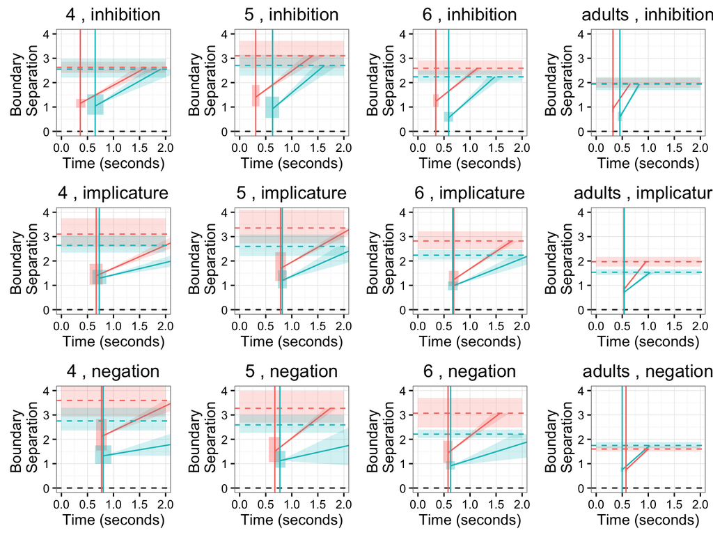

```r
#Visualize diffusion process for each game & trial type
games <- c("inhibition", "implicature", "negation")
age <- unique(sub.pars.ms$Age)
p <- list()

#graph axes
x <- 2
y <- 4

for (a in 1:length(age)) {
    for (g in 1:length(games)) {
    params <- sub.pars.ms %>%
      subset(Game == games[g] & Age == age[a]) %>%
      gather(Name, Value, M:cil) %>%
      unite(Stats, Param, Name) %>%
      spread(Stats, Value)
    params$yint_M = (params$Bias_M*params$Separation_M) - (params$Drift_M*params$Non.Decision_M)
    params$yint_cih = (params$Bias_M*params$Separation_M) - (params$Drift_cih*params$Non.Decision_M)
    params$yint_cil = (params$Bias_M*params$Separation_M) - (params$Drift_cil*params$Non.Decision_M)

    drift_ribbon <- data.frame(xvals = c(params$Non.Decision_M, #non-decision time
                                         (params$Separation_M - params$yint_cih) / params$Drift_cih, #Point where high drift line hits separation boundary
                                         (params$Separation_M - params$yint_M) / params$Drift_M, #Point where drift line hits separation boundary
                                         ifelse(params$Drift_cil > 0, (params$Separation_M - params$yint_cil) / params$Drift_cil, (0 - params$yint_cil) / params$Drift_cil)), #Point where low drift line hits separation boundary or 0
                               ymin = c(params$Bias_M * params$Separation_M, #point where drift starts
                                        params$Drift_cil*((params$Separation_M - params$yint_cih) / params$Drift_cih) + params$yint_cil, #point where low drift is when high drift ends
                                        params$Drift_cil*((params$Separation_M - params$yint_M) / params$Drift_M) + params$yint_cil, #point where low drift is when drift ends
                                        ifelse(params$Drift_cil > 0, params$Separation_M, 0)), #point where low drift ends
                               ymax = c(params$Bias_M * params$Separation_M, #point where drift starts
                                        params$Separation_M, #point where drift ends
                                         params$Separation_M, #point where drift ends
                                        params$Separation_M),#point where drift ends
                               Trial.Type = rep(params$Trial.Type, 4))

    nd_ribbon <- data.frame(xmin = params$Non.Decision_cil,
                            xmax = params$Non.Decision_cih,
                            ymin = rep(params$Bias_cil*params$Separation_cil, 2),
                            ymax = rep(params$Bias_cih*params$Separation_cih, 2),
                            Trial.Type = params$Trial.Type)

    sep_ribbon <- data.frame(xmin = rep(c(0), 2),
                             xmax = rep(x, 2),
                             ymin = params$Separation_cil,
                             ymax = params$Separation_cih,
                             Trial.Type = params$Trial.Type)

    df <- data.frame()

    p[[g + 3*(a-1)]] <- ggplot(df) + coord_cartesian(xlim = c(0, x), ylim = c(0, y)) +
      geom_point() +  theme_bw() +
      geom_segment(data = params,
                   aes(x = Non.Decision_M,
                       xend = (Separation_M - yint_M) / Drift_M,
                       y = Bias_M * Separation_M, yend = Separation_M,
                       color = Trial.Type)) +
      geom_rect(data = nd_ribbon,
                aes(xmin = xmin,
                    xmax = xmax,
                    ymin = ymin,
                    ymax = ymax,
                    fill = Trial.Type),
                alpha=0.2) +
      geom_ribbon(data = drift_ribbon,
                  aes(x = xvals,
                      ymin = ymin,
                      ymax = ymax,
                      fill = Trial.Type),
                  alpha=0.2) +
      geom_rect(data = sep_ribbon,
                aes(xmin = xmin,
                    xmax = xmax,
                    ymin = ymin,
                    ymax = ymax,
                    fill = Trial.Type),
                alpha=0.2) +
      geom_hline(data = params,
                 aes(yintercept = Separation_M, color = Trial.Type),
                 linetype = "dashed") +
      geom_hline(yintercept = 0, linetype = "dashed") +
      geom_vline(data = params,
                 aes(xintercept = Non.Decision_M, color = Trial.Type)) +
      scale_fill_discrete(guide = FALSE) +
      scale_color_discrete(guide = FALSE) +
      xlab("Time (seconds)") + ylab(paste("Boundary \n Separation")) +
      ggtitle(paste(age[a], ",", games[g], sep = " "))
  }
}

plotlist <- c(list(p[[1]], p[[4]], p[[7]], p[[10]],
                   p[[2]], p[[5]], p[[8]], p[[11]],
                   p[[3]], p[[6]], p[[9]], p[[12]]), ncol = 4, nrow = 3)
do.call(grid.arrange, plotlist)
```

Pink = control trials and green = target trials (I removed the legend to make more space)

# DDM Statistics

## Adult data t-tests

Some t-tests to compare parameter values across trial types for adults in different games.

```r
sub.pars$Age <- factor(sub.pars$Age, levels = c("adults", "4", "5", "6"))
sub.pars$Trial.Type <- factor(sub.pars$Trial.Type)

#adult t tests
inhib.bias <- sub.pars %>%
  filter(Age == "adults", Game == "inhibition") %>%
  select(Bias, SubID, Trial.Type) %>%
  spread(Trial.Type, Bias)

t.test(inhib.bias$Control, inhib.bias$Target, paired = T)
```

```
##
##  Paired t-test
##
## data:  inhib.bias$Control and inhib.bias$Target
## t = 4.9146, df = 43, p-value = 1.338e-05
## alternative hypothesis: true difference in means is not equal to 0
## 95 percent confidence interval:
##  0.09938123 0.23770079
## sample estimates:
## mean of the differences
##                0.168541
```

```r
inhib.nd <- sub.pars %>%
  filter(Age == "adults", Game == "inhibition") %>%
  select(Non.Decision, SubID, Trial.Type) %>%
  spread(Trial.Type, Non.Decision)

t.test(inhib.nd$Control, inhib.nd$Target, paired = T)
```

```
##
##  Paired t-test
##
## data:  inhib.nd$Control and inhib.nd$Target
## t = -9.3618, df = 43, p-value = 6.144e-12
## alternative hypothesis: true difference in means is not equal to 0
## 95 percent confidence interval:
##  -0.1669209 -0.1077518
## sample estimates:
## mean of the differences
##              -0.1373363
```

```r
imp.sep <- sub.pars %>%
  filter(Age == "adults", Game == "implicature") %>%
  select(Separation, SubID, Trial.Type) %>%
  spread(Trial.Type, Separation)

t.test(imp.sep$Control, imp.sep$Target, paired = T)
```

```
##
##  Paired t-test
##
## data:  imp.sep$Control and imp.sep$Target
## t = 4.2129, df = 44, p-value = 0.000123
## alternative hypothesis: true difference in means is not equal to 0
## 95 percent confidence interval:
##  0.2223478 0.6301862
## sample estimates:
## mean of the differences
##                0.426267
```

```r
imp.drift <- sub.pars %>%
  filter(Age == "adults", Game == "implicature") %>%
  select(Drift, SubID, Trial.Type) %>%
  spread(Trial.Type, Drift)

t.test(imp.drift$Control, imp.drift$Target, paired = T)
```

```
##
##  Paired t-test
##
## data:  imp.drift$Control and imp.drift$Target
## t = 7.1506, df = 44, p-value = 6.88e-09
## alternative hypothesis: true difference in means is not equal to 0
## 95 percent confidence interval:
##  0.8029908 1.4332671
## sample estimates:
## mean of the differences
##                1.118129
```

```r
neg.drift <- sub.pars %>%
  filter(Age == "adults", Game == "negation") %>%
  select(Drift, SubID, Trial.Type) %>%
  spread(Trial.Type, Drift)

t.test(neg.drift$Control, neg.drift$Target, paired = T)
```

```
##
##  Paired t-test
##
## data:  neg.drift$Control and neg.drift$Target
## t = 0.80172, df = 43, p-value = 0.4271
## alternative hypothesis: true difference in means is not equal to 0
## 95 percent confidence interval:
##  -0.1117470  0.2592219
## sample estimates:
## mean of the differences
##              0.07373745
```

```r
neg.nd <- sub.pars %>%
  filter(Age == "adults", Game == "negation") %>%
  select(Non.Decision, SubID, Trial.Type) %>%
  spread(Trial.Type, Non.Decision)

t.test(neg.nd$Control, neg.nd$Target, paired = T)
```

```
##
##  Paired t-test
##
## data:  neg.nd$Control and neg.nd$Target
## t = 5.6812, df = 43, p-value = 1.062e-06
## alternative hypothesis: true difference in means is not equal to 0
## 95 percent confidence interval:
##  0.04892255 0.10276989
## sample estimates:
## mean of the differences
##              0.07584622
```

## General Developmental Change

Do children’s parameter values change across development, regardless of game?

```r
#Look at changes in paramaters in general across age:
sep.model <- lm(Separation ~ Age, data = sub.pars)
kable(summary(sep.model)$coefficients, digits = 3)
```

|  | Estimate | Std. Error | t value | Pr(>\|t\|) |
| --- | --- | --- | --- | --- |
| (Intercept) | 1.793 | 0.057 | 31.613 | 0 |
| Age4 | 1.085 | 0.102 | 10.638 | 0 |
| Age5 | 1.152 | 0.107 | 10.794 | 0 |
| Age6 | 0.740 | 0.096 | 7.682 | 0 |

```r
nd.model <- lm(Non.Decision ~ Age, data = sub.pars)
kable(summary(nd.model)$coefficients, digits = 3)
```

|  | Estimate | Std. Error | t value | Pr(>\|t\|) |
| --- | --- | --- | --- | --- |
| (Intercept) | 0.486 | 0.014 | 34.835 | 0 |
| Age4 | 0.177 | 0.025 | 7.038 | 0 |
| Age5 | 0.176 | 0.026 | 6.689 | 0 |
| Age6 | 0.097 | 0.024 | 4.082 | 0 |

```r
bias.model <- lm(Bias ~ Age, data = sub.pars)
kable(summary(bias.model)$coefficients, digits = 3)
```

|  | Estimate | Std. Error | t value | Pr(>\|t\|) |
| --- | --- | --- | --- | --- |
| (Intercept) | 0.427 | 0.009 | 48.899 | 0.000 |
| Age4 | 0.049 | 0.016 | 3.118 | 0.002 |
| Age5 | 0.017 | 0.016 | 1.034 | 0.301 |
| Age6 | -0.015 | 0.015 | -0.983 | 0.326 |

```r
drift.model <- lm(Drift ~ Age, data = sub.pars)
kable(summary(drift.model)$coefficients, digits = 3)
```

|  | Estimate | Std. Error | t value | Pr(>\|t\|) |
| --- | --- | --- | --- | --- |
| (Intercept) | 2.491 | 0.057 | 44.068 | 0 |
| Age4 | -1.634 | 0.102 | -16.080 | 0 |
| Age5 | -1.222 | 0.106 | -11.486 | 0 |
| Age6 | -1.125 | 0.096 | -11.724 | 0 |

```r
#Look at continuous across age group, just children
sub.pars.cont <- filter(sub.pars, Age != "adults")
sub.pars.cont$Age <- as.numeric(as.character(sub.pars.cont$Age))

cont.sep.model <- lm(Separation ~ Age, data = sub.pars.cont)
kable(summary(cont.sep.model)$coefficients, digits = 3)
```

|  | Estimate | Std. Error | t value | Pr(>\|t\|) |
| --- | --- | --- | --- | --- |
| (Intercept) | 3.666 | 0.348 | 10.538 | 0.000 |
| Age | -0.178 | 0.068 | -2.630 | 0.009 |

```r
cont.nd.model <- lm(Non.Decision ~ Age, data = sub.pars.cont)
kable(summary(cont.nd.model)$coefficients, digits = 3)
```

|  | Estimate | Std. Error | t value | Pr(>\|t\|) |
| --- | --- | --- | --- | --- |
| (Intercept) | 0.838 | 0.090 | 9.361 | 0.00 |
| Age | -0.041 | 0.017 | -2.342 | 0.02 |

```r
cont.bias.model <- lm(Bias ~ Age, data = sub.pars.cont)
kable(summary(cont.bias.model)$coefficients, digits = 3)
```

|  | Estimate | Std. Error | t value | Pr(>\|t\|) |
| --- | --- | --- | --- | --- |
| (Intercept) | 0.602 | 0.049 | 12.36 | 0.000 |
| Age | -0.032 | 0.009 | -3.34 | 0.001 |

```r
cont.drift.model <- lm(Drift ~ Age, data = sub.pars.cont)
kable(summary(cont.drift.model)$coefficients, digits = 3)
```

|  | Estimate | Std. Error | t value | Pr(>\|t\|) |
| --- | --- | --- | --- | --- |
| (Intercept) | -0.097 | 0.256 | -0.378 | 0.705 |
| Age | 0.251 | 0.050 | 5.028 | 0.000 |

## Developmental Change across games

Does children’s development look different in different games?

```r
##inhibition game
inhib <- filter(sub.pars, Game == "inhibition")

inhib.sep <- lm(Separation ~ Age * Trial.Type, data = inhib)
kable(summary(inhib.sep)$coefficients, digits = 3)
```

|  | Estimate | Std. Error | t value | Pr(>\|t\|) |
| --- | --- | --- | --- | --- |
| (Intercept) | 1.966 | 0.122 | 16.073 | 0.000 |
| Age4 | 0.664 | 0.220 | 3.015 | 0.003 |
| Age5 | 1.139 | 0.228 | 4.995 | 0.000 |
| Age6 | 0.625 | 0.210 | 2.974 | 0.003 |
| Trial.TypeTarget | -0.026 | 0.175 | -0.148 | 0.883 |
| Age4:Trial.TypeTarget | -0.048 | 0.318 | -0.151 | 0.880 |
| Age5:Trial.TypeTarget | -0.372 | 0.330 | -1.128 | 0.260 |
| Age6:Trial.TypeTarget | -0.325 | 0.297 | -1.097 | 0.274 |

```r
inhib.nd <- lm(Non.Decision ~ Age * Trial.Type, data = inhib)
kable(summary(inhib.nd)$coefficients, digits = 3)
```

|  | Estimate | Std. Error | t value | Pr(>\|t\|) |
| --- | --- | --- | --- | --- |
| (Intercept) | 0.322 | 0.028 | 11.451 | 0.000 |
| Age4 | 0.040 | 0.051 | 0.801 | 0.424 |
| Age5 | -0.014 | 0.052 | -0.268 | 0.789 |
| Age6 | 0.021 | 0.048 | 0.441 | 0.659 |
| Trial.TypeTarget | 0.133 | 0.040 | 3.319 | 0.001 |
| Age4:Trial.TypeTarget | 0.153 | 0.073 | 2.092 | 0.038 |
| Age5:Trial.TypeTarget | 0.191 | 0.076 | 2.518 | 0.013 |
| Age6:Trial.TypeTarget | 0.115 | 0.068 | 1.682 | 0.094 |

```r
inhib.bias <- lm(Bias ~ Age * Trial.Type, data = inhib)
kable(summary(inhib.bias)$coefficients, digits = 3)
```

|  | Estimate | Std. Error | t value | Pr(>\|t\|) |
| --- | --- | --- | --- | --- |
| (Intercept) | 0.469 | 0.023 | 20.254 | 0.000 |
| Age4 | -0.032 | 0.042 | -0.763 | 0.446 |
| Age5 | -0.017 | 0.043 | -0.392 | 0.695 |
| Age6 | 0.005 | 0.040 | 0.115 | 0.909 |
| Trial.TypeTarget | -0.167 | 0.033 | -5.043 | 0.000 |
| Age4:Trial.TypeTarget | 0.136 | 0.060 | 2.263 | 0.025 |
| Age5:Trial.TypeTarget | 0.057 | 0.063 | 0.907 | 0.365 |
| Age6:Trial.TypeTarget | -0.057 | 0.056 | -1.016 | 0.311 |

```r
inhib.drift <- lm(Drift ~ Age * Trial.Type, data = inhib)
kable(summary(inhib.drift)$coefficients, digits = 3)
```

|  | Estimate | Std. Error | t value | Pr(>\|t\|) |
| --- | --- | --- | --- | --- |
| (Intercept) | 3.119 | 0.126 | 24.695 | 0.000 |
| Age4 | -1.954 | 0.227 | -8.597 | 0.000 |
| Age5 | -1.565 | 0.235 | -6.648 | 0.000 |
| Age6 | -1.417 | 0.217 | -6.523 | 0.000 |
| Trial.TypeTarget | 0.515 | 0.181 | 2.850 | 0.005 |
| Age4:Trial.TypeTarget | -0.475 | 0.328 | -1.448 | 0.149 |
| Age5:Trial.TypeTarget | -0.278 | 0.341 | -0.816 | 0.416 |
| Age6:Trial.TypeTarget | -0.322 | 0.306 | -1.053 | 0.294 |

```r
##implicature game
imp <- filter(sub.pars, Game == "implicature")

imp.sep <- lm(Separation ~ Age * Trial.Type, data = imp)
kable(summary(imp.sep)$coefficients, digits = 3)
```

|  | Estimate | Std. Error | t value | Pr(>\|t\|) |
| --- | --- | --- | --- | --- |
| (Intercept) | 1.969 | 0.133 | 14.838 | 0.000 |
| Age4 | 1.134 | 0.237 | 4.785 | 0.000 |
| Age5 | 1.385 | 0.250 | 5.535 | 0.000 |
| Age6 | 0.852 | 0.224 | 3.810 | 0.000 |
| Trial.TypeTarget | -0.433 | 0.187 | -2.318 | 0.021 |
| Age4:Trial.TypeTarget | -0.028 | 0.332 | -0.084 | 0.933 |
| Age5:Trial.TypeTarget | -0.324 | 0.357 | -0.908 | 0.365 |
| Age6:Trial.TypeTarget | -0.150 | 0.320 | -0.469 | 0.640 |

```r
imp.nd <- lm(Non.Decision ~ Age * Trial.Type, data = imp)
kable(summary(imp.nd)$coefficients, digits = 3)
```

|  | Estimate | Std. Error | t value | Pr(>\|t\|) |
| --- | --- | --- | --- | --- |
| (Intercept) | 0.531 | 0.029 | 18.035 | 0.000 |
| Age4 | 0.136 | 0.053 | 2.580 | 0.011 |
| Age5 | 0.254 | 0.056 | 4.568 | 0.000 |
| Age6 | 0.155 | 0.050 | 3.122 | 0.002 |
| Trial.TypeTarget | 0.007 | 0.041 | 0.165 | 0.869 |
| Age4:Trial.TypeTarget | 0.052 | 0.074 | 0.707 | 0.480 |
| Age5:Trial.TypeTarget | 0.025 | 0.079 | 0.314 | 0.754 |
| Age6:Trial.TypeTarget | -0.026 | 0.071 | -0.372 | 0.710 |

```r
imp.bias <- lm(Bias ~ Age * Trial.Type, data = imp)
kable(summary(imp.bias)$coefficients, digits = 3)
```

|  | Estimate | Std. Error | t value | Pr(>\|t\|) |
| --- | --- | --- | --- | --- |
| (Intercept) | 0.420 | 0.018 | 23.934 | 0.000 |
| Age4 | 0.028 | 0.031 | 0.899 | 0.370 |
| Age5 | 0.085 | 0.033 | 2.576 | 0.011 |
| Age6 | 0.017 | 0.030 | 0.573 | 0.567 |
| Trial.TypeTarget | 0.048 | 0.025 | 1.938 | 0.054 |
| Age4:Trial.TypeTarget | -0.007 | 0.044 | -0.158 | 0.875 |
| Age5:Trial.TypeTarget | -0.091 | 0.047 | -1.928 | 0.055 |
| Age6:Trial.TypeTarget | -0.052 | 0.042 | -1.239 | 0.217 |

```r
imp.drift <- lm(Drift ~ Age * Trial.Type, data = imp)
kable(summary(imp.drift)$coefficients, digits = 3)
```

|  | Estimate | Std. Error | t value | Pr(>\|t\|) |
| --- | --- | --- | --- | --- |
| (Intercept) | 2.697 | 0.095 | 28.535 | 0.000 |
| Age4 | -1.755 | 0.169 | -10.395 | 0.000 |
| Age5 | -1.486 | 0.178 | -8.336 | 0.000 |
| Age6 | -1.276 | 0.159 | -8.010 | 0.000 |
| Trial.TypeTarget | -1.063 | 0.133 | -7.993 | 0.000 |
| Age4:Trial.TypeTarget | 0.627 | 0.236 | 2.652 | 0.009 |
| Age5:Trial.TypeTarget | 0.795 | 0.254 | 3.127 | 0.002 |
| Age6:Trial.TypeTarget | 0.494 | 0.228 | 2.168 | 0.031 |

```r
##negation game
neg <- filter(sub.pars, Game == "negation")

neg.sep <- lm(Separation ~ Age * Trial.Type, data = neg)
kable(summary(neg.sep)$coefficients, digits = 3)
```

|  | Estimate | Std. Error | t value | Pr(>\|t\|) |
| --- | --- | --- | --- | --- |
| (Intercept) | 1.602 | 0.147 | 10.890 | 0.000 |
| Age4 | 1.992 | 0.267 | 7.455 | 0.000 |
| Age5 | 1.672 | 0.272 | 6.143 | 0.000 |
| Age6 | 1.469 | 0.248 | 5.927 | 0.000 |
| Trial.TypeTarget | 0.147 | 0.208 | 0.705 | 0.481 |
| Age4:Trial.TypeTarget | -0.985 | 0.375 | -2.629 | 0.009 |
| Age5:Trial.TypeTarget | -0.828 | 0.385 | -2.152 | 0.033 |
| Age6:Trial.TypeTarget | -1.005 | 0.351 | -2.867 | 0.005 |

```r
neg.nd <- lm(Non.Decision ~ Age * Trial.Type , data = neg)
kable(summary(neg.nd)$coefficients, digits = 3)
```

|  | Estimate | Std. Error | t value | Pr(>\|t\|) |
| --- | --- | --- | --- | --- |
| (Intercept) | 0.572 | 0.031 | 18.565 | 0.000 |
| Age4 | 0.198 | 0.056 | 3.541 | 0.000 |
| Age5 | 0.102 | 0.057 | 1.796 | 0.074 |
| Age6 | 0.006 | 0.052 | 0.107 | 0.915 |
| Trial.TypeTarget | -0.074 | 0.044 | -1.692 | 0.092 |
| Age4:Trial.TypeTarget | 0.104 | 0.079 | 1.327 | 0.186 |
| Age5:Trial.TypeTarget | 0.171 | 0.081 | 2.124 | 0.035 |
| Age6:Trial.TypeTarget | 0.124 | 0.073 | 1.683 | 0.094 |

```r
neg.bias <- lm(Bias ~ Age * Trial.Type, data = neg)
kable(summary(neg.bias)$coefficients, digits = 3)
```

|  | Estimate | Std. Error | t value | Pr(>\|t\|) |
| --- | --- | --- | --- | --- |
| (Intercept) | 0.466 | 0.018 | 26.455 | 0.000 |
| Age4 | 0.123 | 0.032 | 3.852 | 0.000 |
| Age5 | -0.006 | 0.033 | -0.179 | 0.858 |
| Age6 | 0.004 | 0.030 | 0.146 | 0.884 |
| Trial.TypeTarget | -0.037 | 0.025 | -1.495 | 0.136 |
| Age4:Trial.TypeTarget | -0.072 | 0.045 | -1.614 | 0.108 |
| Age5:Trial.TypeTarget | 0.010 | 0.046 | 0.222 | 0.824 |
| Age6:Trial.TypeTarget | -0.021 | 0.042 | -0.498 | 0.619 |

```r
neg.drift <- lm(Drift ~ Age * Trial.Type, data = neg)
kable(summary(neg.drift)$coefficients, digits = 3)
```

|  | Estimate | Std. Error | t value | Pr(>\|t\|) |
| --- | --- | --- | --- | --- |
| (Intercept) | 2.010 | 0.114 | 17.641 | 0.000 |
| Age4 | -0.990 | 0.207 | -4.781 | 0.000 |
| Age5 | -0.352 | 0.211 | -1.669 | 0.097 |
| Age6 | -0.381 | 0.192 | -1.984 | 0.049 |
| Trial.TypeTarget | -0.130 | 0.161 | -0.805 | 0.421 |
| Age4:Trial.TypeTarget | -0.534 | 0.290 | -1.838 | 0.067 |
| Age5:Trial.TypeTarget | -1.055 | 0.298 | -3.541 | 0.000 |
| Age6:Trial.TypeTarget | -0.834 | 0.272 | -3.072 | 0.002 |